# Clase 3

Mario Matus

July 05, 2016

# Modelo de Regresión Básico

- Mínimos cuadrados es una herramienta de estimación.
- Para realizar inferencia se desarrolla un modelo probabilístico de regresión lineal
  $$Y_i = \beta_0 + \beta_1 X_i + \varepsilon_{i}$$
- Aquí $\varepsilon_{i}$ se asume iid $N(0, \sigma^2)$.
- Note que $E[Y_i ~|~ X_i = x_i] = \mu_i = \beta_0 + \beta_1 x_i$
- Note que $Var(Y_i ~|~ X_i = x_i) = \sigma^2$.
- La estimación por ML de $\beta_0$ y $\beta_1$ coincide con la estimación por OLS
  $$\hat \beta_1 = Cor(Y, X) \frac{Sd(Y)}{Sd(X)} ~~~ \hat \beta_0 = \bar Y - \hat \beta_1 \bar X$$
- $E[Y ~|~ X = x] = \beta_0 + \beta_1 x$
- $Var(Y ~|~ X = x) = \sigma^2$

# Interpretación de los coeficientes

## Intercepto

- $\beta_0$ es el valor esperado del output cuando el input es 0
  $$E[Y | X = 0] = \beta_0 + \beta_1 \times 0 = \beta_0$$
- Note que esto no siempre es de interés, por ejemplo cuando $X=0$ es imposible o está fuera del rango de los datos (e.g. Si $X$ corresponde a presión sanguínea, estatura, etc.)
- Considere que
  $$Y_i = \beta_0 + \beta_1 X_i + \varepsilon_i
  = \beta_0 + a \beta_1 + \beta_1 (X_i - a) + \varepsilon_i
  = \tilde \beta_0 + \beta_1 (X_i - a) + \varepsilon_i$$
  Entonces, si desplazamos $X$ en $a$ unidades cambia el intercepto pero no la pendiente. menudo $a$ se fija en $\bar X$ tal que el intercepto se interpreta como la respuesta esperada en el valor promedio de $X$.

## Pendiente

- $\beta_1$ es el cambio esperado en el output cuando el input cambia en una unidad
  $$E[Y ~|~ X = x+1] - E[Y ~|~ X = x] =
  \beta_0 + \beta_1 (x + 1) - (\beta_0 + \beta_1 x ) = \beta_1$$
- Considere el impacto de cambiar las unidades (medición) de $X$
  $$Y_i = \beta_0 + \beta_1 X_i + \varepsilon_i
  = \beta_0 + \frac{\beta_1}{a} (X_i a) + \varepsilon_i
  = \beta_0 + \tilde \beta_1 (X_i a) + \varepsilon_i$$
- Entonces, la multiplicación de $X$ por un factor $a$ resulta en que se divide el coeficiente por el mismo factor $a$.
- Si queremos predecir el output dado un valor del input, digamos $X$, el modelo de regresión predice
  $$\hat \beta_0 + \hat \beta_1 X$$

## Ejemplo

- Si $X$ es la estatura en $m$ e $Y$ es el peso en $kg$. Entonces $\beta_1$ es $kg/m$. Convirtiendo $X$ en $cm$ implica multiplicar $X$ por $100 cm/m$. Para obtener $\beta_1$ en las unidades correctas, tenemos que dividir por $100 cm /m$ y así se tendrán las unidades correctas.
  $$X m \times \frac{100cm}{m} = (100 X) cm
  ~~\mbox{y}~~
  \beta_1 \frac{kg}{m} \times\frac{1 m}{100cm} =
  \left(\frac{\beta_1}{100}\right)\frac{kg}{cm}$$

# Modelo Lineal Univariado

## Los Datos de Galton

Francis Galton (1882 - 1911) sentó las bases de la Econometría estudiando la estatura de padres e hijos. Los datos de su estudio están disponibles en la instalación de R. El gráfico de estatura de padres versus estatura de hijos es el siguiente:

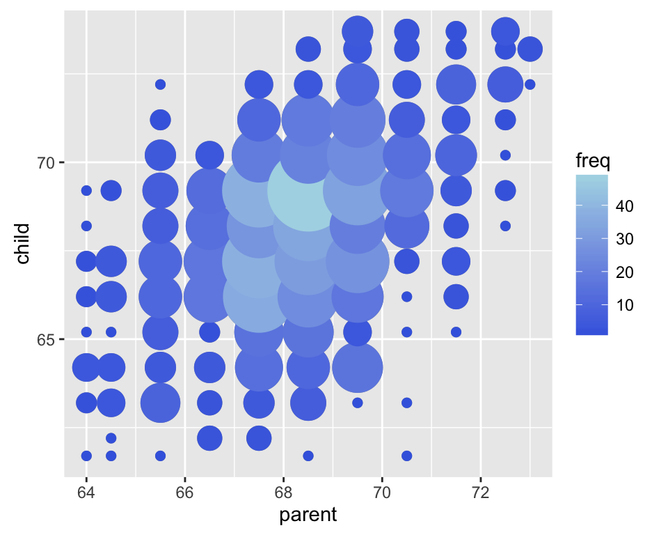

## Ejercicios

- Usar la estatura de los padres para predecir la de los hijos
- Encontrar una relación entre ambas estaturas
- Encontrar la variación de la estatura de los hijos que no depende de la estatura de los padres (variación residual)
- Los supuestos que se necesitan para generalizar más allá de los datos
- Por qué los hijos de padres muy altos tienden a ser más bajos (regresión a la media)

## Análisis de los datos

- Datos recolectados y analizados por Francis Galton en 1885.
- Galton fue un científico que creó los conceptos de correlación y regresión.
- Veremos la distribución marginal de los datos.
- La corrección por género se obtiene multiplicando la estatura de las mujeres por 1,08.

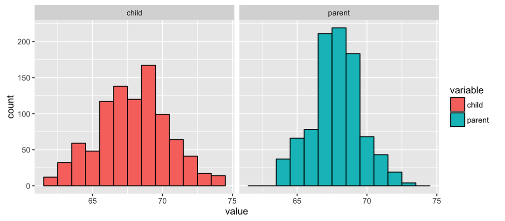

```r
library(reshape); long <- melt(galton)
g <- ggplot(long, aes(x = value, fill = variable))
g <- g + geom_histogram(colour = "black", binwidth=1)
g <- g + facet_grid(. ~ variable)
g
```

## Encontrando la media usando mínimos cuadrados

- Veamos un poco los datos

```r
head(galton, n=10) #primeras 10 observaciones (medidas en pulgadas)
```

```
##    child parent
## 1   61.7   70.5
## 2   61.7   68.5
## 3   61.7   65.5
## 4   61.7   64.5
## 5   61.7   64.0
## 6   62.2   67.5
## 7   62.2   67.5
## 8   62.2   67.5
## 9   62.2   66.5
## 10  62.2   66.5
```

```r
dim(galton) #tamaño muestral = 928 ; variables  = 2
```

```
## [1] 928   2
```

- Considere solo la estatura de los hijos. ¿Cómo se describe la media?
- Una definición es que siendo $Y_i$ la estatura del hijo $i$ para $i= 1,\ldots, n$ con $n=928$ entonces la media es el valor de $\mu$ que minimiza la ecuación $\sum_{i=1}^n (Y_i - \mu)^2$
- Se tiene que $\mu = \bar Y$.

## Regresión

### Sin constante

$$Y_i = \beta_1 X_i + \varepsilon_i$$

```r
lm(child ~ parent -1, data = galton)
```

```
##
## Call:
## lm(formula = child ~ parent - 1, data = galton)
##
## Coefficients:
## parent
## 0.9965
```

### Con constante

$$Y_i = \beta_0 + \beta_1 X_i + \varepsilon_i$$

```r
lm(child ~ parent, data = galton)
```

```
##
## Call:
## lm(formula = child ~ parent, data = galton)
##
## Coefficients:
## (Intercept)       parent
##     23.9415       0.6463
```

### Sin constante (centrando los datos)

$$(Y_i - \bar{Y}) = \beta_1 (X_i - \bar{X}) + \varepsilon_i$$
$$\tilde{Y}_i = \beta_0 \beta_1 \tilde{X}_i + \varepsilon_i$$

```r
lm(I(child - mean(child)) ~ I(parent - mean(parent)) -1, data = galton)
```

```
##
## Call:
## lm(formula = I(child - mean(child)) ~ I(parent - mean(parent)) -
##     1, data = galton)
##
## Coefficients:
## I(parent - mean(parent))
##                   0.6463
```

$$(Y_i - \bar{Y}) = \beta_0 + \beta_1 (X_i - \bar{X}) + \varepsilon_i$$
$$\tilde{Y}_i = \beta_0 \beta_1 \tilde{X}_i + \varepsilon_i$$

```r
lm(I(child - mean(child)) ~ I(parent - mean(parent)) -1, data = galton)
```

```
##
## Call:
## lm(formula = I(child - mean(child)) ~ I(parent - mean(parent)) -
##     1, data = galton)
##
## Coefficients:
## I(parent - mean(parent))
##                   0.6463
```

### Gráfico

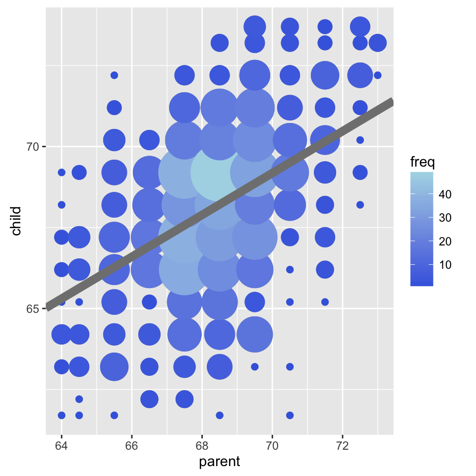

## Ajuste de la mejor recta de regresión

- Sea $Y_i$ la estatura del hijo $i^{th}$ y $X_i$ la estatura del padre $i^{th}$.
- Considere la recta con mejor ajuste $Y_i = \beta_0 + \beta_1 X_i + \varepsilon_i$.
- La ecuación de mínimos cuadrados es
  $$\sum_{i=1}^n [Y_i - (\beta_0 + \beta_1 X_i)]^2.$$

## Resultados

- El modelo de mínimos cuadrados ajusta la recta $Y = \beta_0 + \beta_1 X$ a través de los pares ordenados $(X_i, Y_i)$ e $Y_i$ es el output que se obtiene de la recta $Y = \hat \beta_0 + \hat \beta_1 X$ con
  $$\hat \beta_1 = Cor(Y, X) \frac{Sd(Y)}{Sd(X)} ~~~ \hat \beta_0 = \bar Y - \hat \beta_1 \bar X.$$
- $\hat \beta_1$ se expresa en unidades de $Y / X$, $\hat \beta_0$ se expresa en unidades de $Y$.
- La recta de regresión pasa por $(\bar X, \bar Y)$.
- La pendiente de la recta de regresión con $X$ como output e $Y$ como input es $Cor(Y, X) \frac{Sd(X)}{Sd(Y)}$.
- La pendiente es la misma que se obtiene que si se centraran los datos $(X_i - \bar X, Y_i - \bar Y)$ y se estimara una regresión que pasa por $(0,0)$.
- Si se normalizan los datos $\left(\displaystyle\frac{X_i - \bar X}{Sd(X)}, \displaystyle\frac{Y_i - \bar Y}{Sd(Y)} \right)$, la pendiente es $Cor(Y, X)$.

## En síntesis

Es interesante notar que las estimaciones del programa coinciden con el cálculo siguiendo las fórmulas por definición.

```r
y <- galton$child
x <- galton$parent
beta1 <- cor(y, x) *  sd(y) / sd(x)
beta0 <- mean(y) - beta1 * mean(x)
rbind(c(beta0, beta1), coef(lm(y ~ x)))
```

```
##      (Intercept)         x
## [1,]    23.94153 0.6462906
## [2,]    23.94153 0.6462906
```

La regresión desde el origen conserva la pendiente si primero centramos los datos

```r
yc <- y - mean(y)
xc <- x - mean(x)
beta1 <- sum(yc * xc) / sum(xc ^ 2)
c(beta1, coef(lm(y ~ x))[2])
```

```
##                   x
## 0.6462906 0.6462906
```

Si se normalizan los datos la pendiente es igual al coeficiente de correlación

```r
yn <- (y - mean(y))/sd(y)
xn <- (x - mean(x))/sd(x)
c(cor(y, x), cor(yn, xn), coef(lm(yn ~ xn))[2])
```

```
##                            xn
## 0.4587624 0.4587624 0.4587624
```

Mejor recta de regresión:

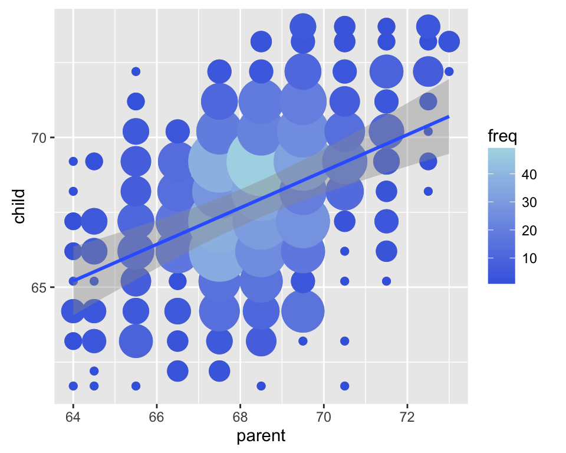

# Modelo Lineal Multivariado

## Extensión del caso univariado

- El modelo lineal generalizado extiende el modelo lineal simple (SLR) agregando términos linealmente al modelo. Típicamente $X_{1i}=1$ (se incluye un intercepto).
  $$Y_i = \beta_1 X_{1i} + \beta_2 X_{2i} + \ldots +
  \beta_{p} X_{pi} + \epsilon_{i}
  = \sum_{k=1}^p X_{ik} \beta_j + \varepsilon_{i}.$$
- La estimación por OLS (y también la estimación por ML bajo supuestos de iid y errores Gaussianos) minimiza
  $$\sum_{i=1}^n \left(Y_i - \sum_{k=1}^p X_{ki} \beta_j\right)^2.$$
- Lo importante es la linealidad de los coeficientes, entonces
  $$Y_i = \beta_1 X_{1i}^2 + \beta_2 X_{2i}^2 + \ldots +
  \beta_{p} X_{pi}^2 + \varepsilon_{i}.$$
  también es un modelo lineal (aunque los regresores sean términos cuadráticos).

## Interpretación de los coeficientes

$$E[Y | X_1 = x_1, \ldots, X_p = x_p] = \sum_{k=1}^p x_{k} \beta_k$$

$$E[Y | X_1 = x_1 + 1, \ldots, X_p = x_p] = (x_1 + 1) \beta_1 + \sum_{k=2}^p x_{k} \beta_k$$

# Tasas de hambre en la población infantil

Instancia de trabajo

```r
#link descarga
url <- "http://apps.who.int/gho/athena/data/GHO/WHOSIS_000008.csv"
file <- "hunger.csv"

if(!file.exists(file)) {
  print("descargando")
  download.file(url, file, method="curl")
}

hunger <- read.csv("hunger.csv")
hunger <- hunger[hunger$Sex!="Both sexes",]
```

Sin controlar por género:

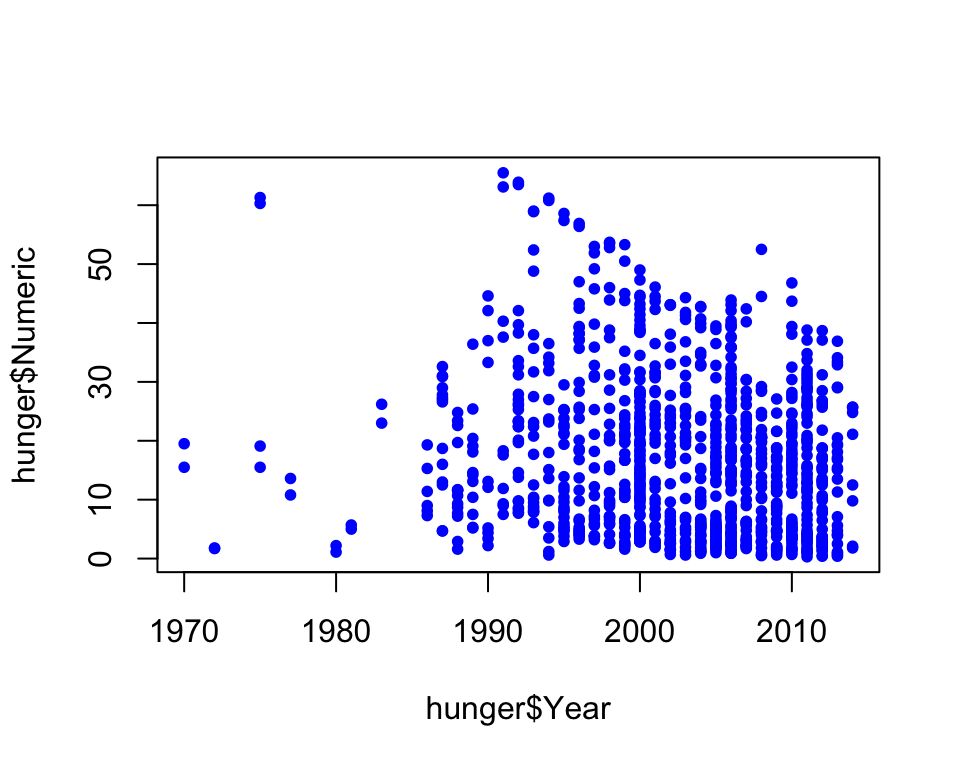

```r
lm1 <- lm(hunger$Numeric ~ hunger$Year)
plot(hunger$Year,hunger$Numeric,pch=20,col="blue")
```

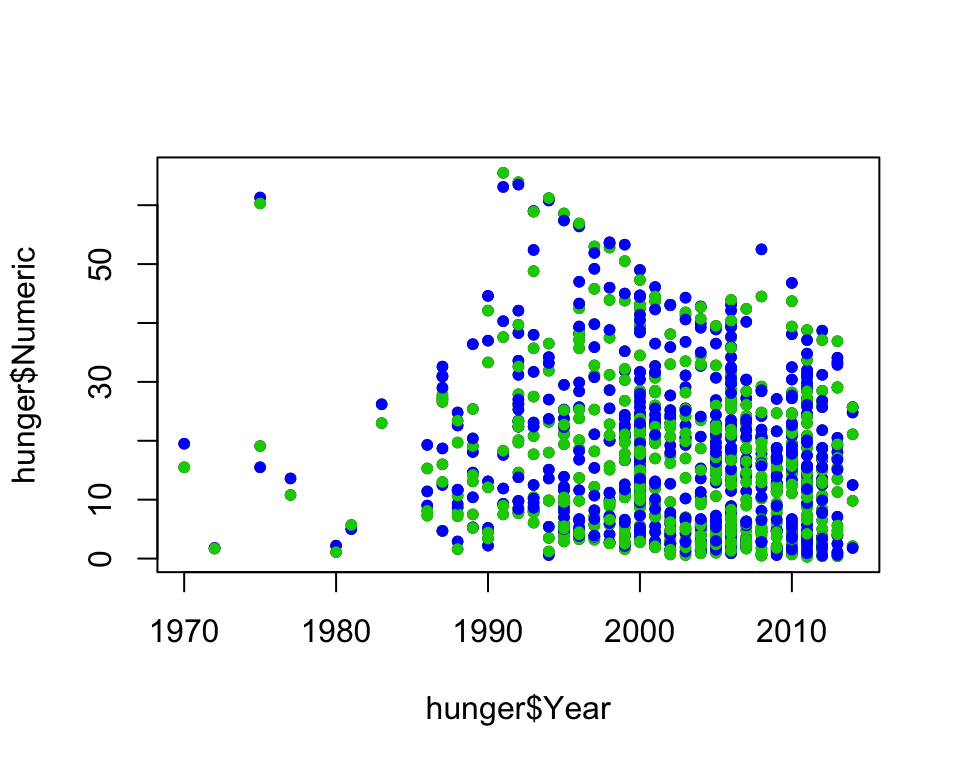

```r
plot(hunger$Year,hunger$Numeric,pch=20)
#azul=niñas verde=niños
points(hunger$Year,hunger$Numeric,pch=20,col=((hunger$Sex=="Male")*1+3))
```

## Modelo univariado

Sin controlar por género:

$$Hu_i = b_0 + b_1 Y_i + e_i$$

$b_0$ = % de hambre en el año 0

$b_1$ = disminución del % de hambre por año

$e_i$ = todas las variables no medidas

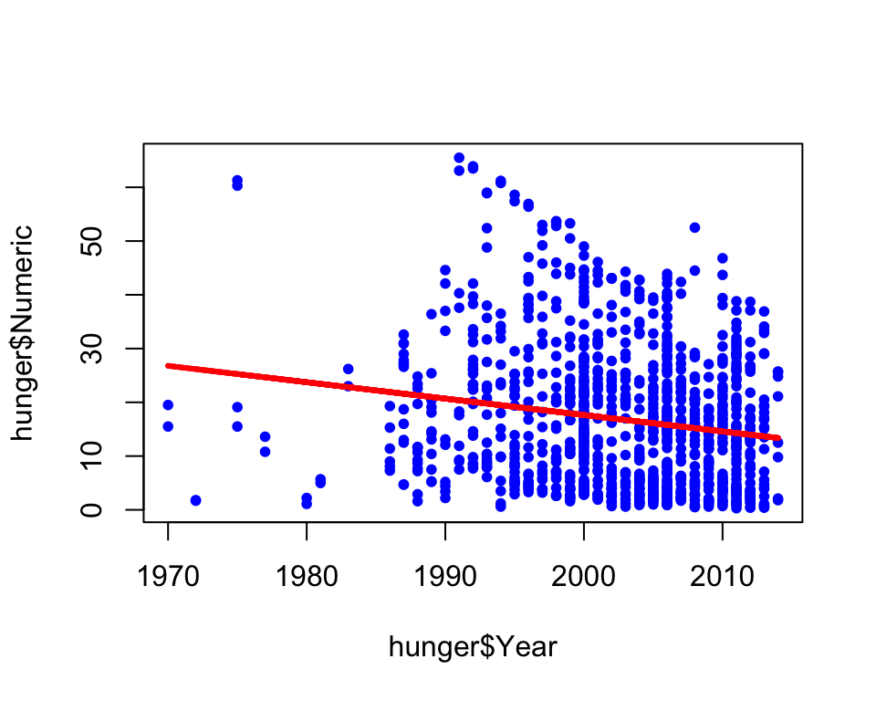

```r
lm1 <- lm(hunger$Numeric ~ hunger$Year)
plot(hunger$Year,hunger$Numeric,pch=20,col="blue")
lines(hunger$Year,lm1$fitted,lwd=3,col="red")
```

Controlando por género:

$$HuF_i = bf_0 + bf_1 YF_i + ef_i$$

$bf_0$ = % de hambre en las niñas en el año 0

$bf_1$ = disminución del % de hambre por año en las niñas

$ef_i$ = todas las variables no medidas

$$HuM_i = bm_0 + bm_1 YM_i + em_i$$

$bm_0$ = % de hambre en los niños en el año 0

$bm_1$ = disminución del % de hambre por año en las niños

$em_i$ = todas las variables no medidas

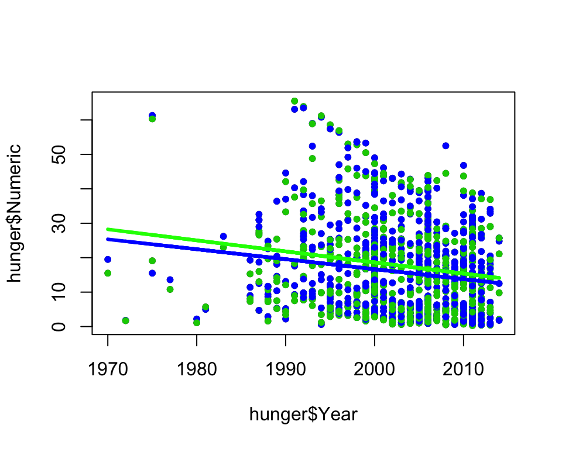

```r
lmM <- lm(hunger$Numeric[hunger$Sex=="Male"] ~ hunger$Year[hunger$Sex=="Male"])
lmF <- lm(hunger$Numeric[hunger$Sex=="Female"] ~ hunger$Year[hunger$Sex=="Female"])
plot(hunger$Year,hunger$Numeric,pch=20)
points(hunger$Year,hunger$Numeric,pch=20,col=((hunger$Sex=="Male")*1+3))
lines(hunger$Year[hunger$Sex=="Male"],lmM$fitted,col="green",lwd=3)
lines(hunger$Year[hunger$Sex=="Female"],lmF$fitted,col="blue",lwd=3)
```

## Modelo multivariado

$$Hu_i = b_0 + b_1 M_i + b_2 Y_i + e^*_i$$

$b_0$ = % de hambre en las niñas en el año 0

$M_i$ = $\begin{cases} 1 &\text{si es niño} \cr 0 &\text{si es niña} \end{cases}$

$b_0 + b_1$ = % de hambre en las niños en el año 0

$b_2$ = disminución del % de hambre por año en niños o niñas

$e^*_i$ = todas las variables no medidas

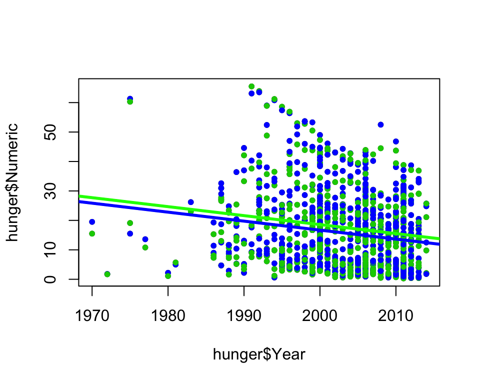

```r
lmBoth <- lm(hunger$Numeric ~ hunger$Year + hunger$Sex)
plot(hunger$Year,hunger$Numeric,pch=20)
points(hunger$Year,hunger$Numeric,pch=20,col=((hunger$Sex=="Male")*1+3))
abline(c(lmBoth$coeff[1],lmBoth$coeff[2]),col="blue",lwd=3)
abline(c(lmBoth$coeff[1] + lmBoth$coeff[3],lmBoth$coeff[2] ),col="green",lwd=3)
```

$$Hu_i = b_0 + b_1 M_i + b_2 Y_i + b_3 (M_i \cdot Y_i) + e^+_i$$

$b_0$ = % de hambre en las niñas en el año 0

$M_i$ = $\begin{cases} 1 &\text{si es niño} \cr 0 &\text{si es niña} \end{cases}$

$b_0 + b_1$ = % de hambre en las niños en el año 0

$b_2$ = disminución del % de hambre por año en niños o niñas

$b_2 + b_3$ = disminución del % de hambre por año en los niños

$e^+_i$ = todas las variables no medidas

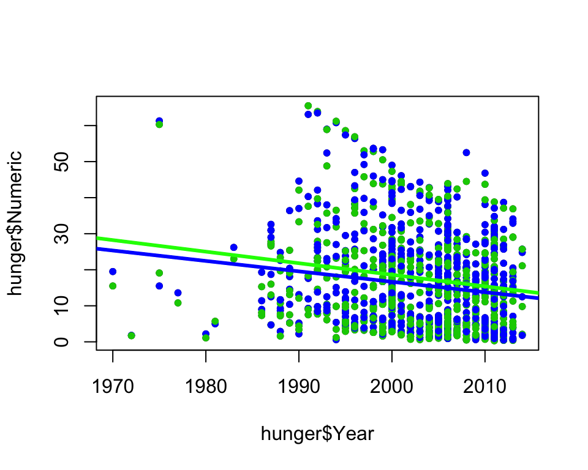

```r
lmBoth <- lm(hunger$Numeric ~ hunger$Year + hunger$Sex + hunger$Sex*hunger$Year)
plot(hunger$Year,hunger$Numeric,pch=20)
points(hunger$Year,hunger$Numeric,pch=20,col=((hunger$Sex=="Male")*1+3))
abline(c(lmBoth$coeff[1],lmBoth$coeff[2]),col="blue",lwd=3)
abline(c(lmBoth$coeff[1] + lmBoth$coeff[3],lmBoth$coeff[2] +lmBoth$coeff[4]),col="green",lwd=3)
```

## Resultados

```r
coefficients(lmBoth)
```

```
##                (Intercept)                hunger$Year
##               595.83543620                -0.28958348
##             hunger$SexMale hunger$Year:hunger$SexMale
##                64.74249171                -0.03139868
```

# Ejercicio

Usando la encuesta [CASEN 2013](http://pachamaltese.github.io/analisis-de-datos-unab/laboratorios/laboratorio4/casen2013.dta.zip) estime un modelo log-lineal
$$\log(y_i) = \beta_0 + \sum_{i=1}^n \beta_i x_i + \varepsilon_i$$
que permita predecir el salario por hora de los profesionales chilenos de entre 35 y 45 años que tienen una jornada laboral de al menos 30 horas por semana.

Considere como regresores las variables:

- Sexo
- Experiencia laboral
- Si la persona reside en la Región Metropolitana
- Si la persona trabaja en la Administración Pública

Extienda los resultados de su regresión a la población del país.

# Desarrollo Ejercicio

```r
#install.packages("foreign")
#install.packages("httr")
#install.packages("plyr")

library(foreign) #para leer archivos de Stata, SPSS, etc
library(httr) #permite descargar desde la web
library(plyr) #comandos útiles para bases de datos

###########################
# Diccionario de variables
###########################

# Lo primero es consultar el diccionario de variables donde aparece la explicación de los códigos y la naturaleza de las variables
# http://observatorio.ministeriodesarrollosocial.gob.cl/documentos/Libro_de_Codigos_Casen_2013_Base_Principal_Metodologia_Nueva.pdf

####################################
# Descargar y cargar base de datos
####################################

url <- "http://pachamaltese.github.io/analisis-de-datos-unab/laboratorio4/casen2013.dta.zip"
zip <- "casen2013.dta.zip"
dta <- "casen2013.dta"

if(!file.exists(zip)) {
  print("descargando")
  download.file(url, file, method="curl")
}

if(!file.exists(dta) & file.exists(zip)) {
  unzip(zip)
  casen <- read.dta(dta)
}

if(file.exists(dta)) {
  casen <- read.dta(dta)
}

####################################
# Limpiar datos y generar variables
####################################

# creo una copia que ahorrará tiempo si quiero retroceder algunos pasos
# o sea, si me equivoco vuelvo a ejecutar esta línea y la variable casen sigue intacta (ahorra tiempo)
data <- casen

# conservo en memoria únicamente las variables relevantes para la regresión
# para esto hay que consultar el diccionario de variables
keep <- c("expr", "yoprcor", "edad", "esc", "sexo", "region", "rama1", "o10")
data <- data[keep]

# veo el tipo de variables en memoria
str(data) #hay variables enteras, factores y numéricas
```

```
## 'data.frame':    218491 obs. of  8 variables:
##  $ expr   : int  32 32 32 32 32 32 32 32 32 32 ...
##  $ yoprcor: int  1200000 450000 NA 450000 NA NA NA NA 700000 500000 ...
##  $ edad   : int  36 30 41 41 10 9 73 73 60 49 ...
##  $ esc    : int  17 17 17 15 NA NA 8 10 17 17 ...
##  $ sexo   : Factor w/ 2 levels "hombre","mujer": 2 2 1 2 2 1 1 2 2 2 ...
##  $ region : Factor w/ 15 levels "i. tarapaca",..: 1 1 1 1 1 1 1 1 1 1 ...
##  $ rama1  : Factor w/ 18 levels "a. agricultura, ganader\xeda, caza y silvicultura",..: 11 11 11 11 NA NA NA NA 12 15 ...
##  $ o10    : int  40 40 45 45 NA NA NA NA 40 45 ...
```

```r
# saco las filas que tengan celdas vacías (o sino habrá que hacer pasos adicionales al final)
data <- na.omit(data)

# hay que crear la variable "logaritmo del salario por hora"
# se consideran los datos de los trabajadores con jornada > 30 horas/semana
# para el cálculo hay que calcular
# salario ($/mes) * 12 (meses/año) / jornada (horas/semana) * 52 (semanas/año)
data <- data[data$o10 > 30,]
data$WHP <- (data$yoprcor*12)/(data$o10*52)
data$logWHP <- log(data$WHP)

# conservo solo los datos que corresponden al tramo de edad entre 35 y 45 años
data <- data[(data$edad >= 35 & data$edad <= 45),]

# conservo solo los datos que corresponden al nivel de escolaridad pedido
# profesional en Chile = 5 años (o más) de educación superior
# entonces Experiencia Laboral = Edad - Años de Escolaridad ("esc") - 5 (duración mínima de estudios profesionales)
# la ecuación de arriba puede tomar valores negativos ya que hay personas en la encuesta que se encuentran estudiando
# y trabajan part-time, realizan continuidad de estudios, tienen post-grado, etc. entonces hay que descartar esos casos
data$exp <- data$edad - data$esc - 5
data <- data[data$exp >= 0,]
data$exp2 <- (data$exp)^2

# hay que generar una variable binaria para cada región
# antes de hacer cualquier cosa veo como están asignados los niveles del factor región
levels(data$region)
```

```
##  [1] "i. tarapaca"            "ii. antofagasta"
##  [3] "iii. atacama"           "iv. coquimbo"
##  [5] "v. valpara\xedso"       "vi. o higgins"
##  [7] "vii. maule"             "viii. biob\xedo"
##  [9] "ix. la araucan\xeda"    "x. los lagos"
## [11] "xi. ays\xe9n"           "xii. magallanes"
## [13] "metropolitana"          "xiv. los r\xedos"
## [15] "xv. arica y parinacota"
```

```r
# los nombres de los niveles contienen espacios, entonces asigno nombres simples
# (ver el excel que usé para hacer que el proceso sea eficiente)
data$region <- revalue(data$region, c("i. tarapaca"="r1",
                                      "ii. antofagasta"="r2",
                                      "iii. atacama"="r3",
                                      "iv. coquimbo"="r4",
                                      "v. valpara\xedso"="r5",
                                      "vi. o higgins"="r6",
                                      "vii. maule"="r7",
                                      "viii. biob\xedo"="r8",
                                      "ix. la araucan\xeda"="r9",
                                      "x. los lagos"="r10",
                                      "xi. ays\xe9n"="r11",
                                      "xii. magallanes"="r12",
                                      "metropolitana"="r13",
                                      "xiv. los r\xedos"="r14",
                                      "xv. arica y parinacota"="r15"))

# verifico que los nombres asignados a los niveles hayan cambiado
levels(data$region)
```

```
##  [1] "r1"  "r2"  "r3"  "r4"  "r5"  "r6"  "r7"  "r8"  "r9"  "r10" "r11"
## [12] "r12" "r13" "r14" "r15"
```

```r
# para crear las variables binarias uso el comando for de manera que no hay que repetir el comando para cada región
for(i in unique(data$region)) {
  data[paste(i, sep="")] <- ifelse(data$region == i, 1, 0)
}

# hay que generar una variable binaria para cada industria (o rama)
# veo como están asignados los niveles del factor región
levels(data$rama1)
```

```
##  [1] "a. agricultura, ganader\xeda, caza y silvicultura"
##  [2] "b. pesca"
##  [3] "c. explotaci\xf3n de minas y canteras"
##  [4] "d. industrias manufactureras"
##  [5] "e. suministro de electricidad, gas y agua"
##  [6] "f.construcci\xf3n"
##  [7] "g. comercio al por mayor y al por menor"
##  [8] "h. hoteles y restaurantes"
##  [9] "i. transporte, almacenamiento y comunicaciones"
## [10] "j. intermediaci\xf3n financiera"
## [11] "k. actividades inmobiliarias, empresariales y de alquiler"
## [12] "l.administrasci\xf3n p\xfablica y defensa"
## [13] "m. ense\xf1anza"
## [14] "n. servicios sociales y de salud"
## [15] "o. otras actividades de servicios comunitarios, sociales y personales"
## [16] "p. hogares privados con servicio dom\xe9stico"
## [17] "q.organizaciones y organos extraterritoriales"
## [18] "x. no bien especificado"
```

```r
# aparece un nivel que corresponde a "sin clasificar" (nivel X), entonces debo sacar ese nivel y volver a definir los niveles
data<-data[data$rama1 != "x. no bien especificado",]
data$rama1 <- factor(data$rama1)

# verifico los cambios
levels(data$rama1)
```

```
##  [1] "a. agricultura, ganader\xeda, caza y silvicultura"
##  [2] "b. pesca"
##  [3] "c. explotaci\xf3n de minas y canteras"
##  [4] "d. industrias manufactureras"
##  [5] "e. suministro de electricidad, gas y agua"
##  [6] "f.construcci\xf3n"
##  [7] "g. comercio al por mayor y al por menor"
##  [8] "h. hoteles y restaurantes"
##  [9] "i. transporte, almacenamiento y comunicaciones"
## [10] "j. intermediaci\xf3n financiera"
## [11] "k. actividades inmobiliarias, empresariales y de alquiler"
## [12] "l.administrasci\xf3n p\xfablica y defensa"
## [13] "m. ense\xf1anza"
## [14] "n. servicios sociales y de salud"
## [15] "o. otras actividades de servicios comunitarios, sociales y personales"
## [16] "p. hogares privados con servicio dom\xe9stico"
## [17] "q.organizaciones y organos extraterritoriales"
```

```r
# los nombres de los niveles contienen espacios, entonces asigno nombres simples
data$rama1 <- revalue(data$rama1, c("a. agricultura, ganader\xeda, caza y silvicultura"="sa",
                                    "b. pesca"="sb",
                                    "c. explotaci\xf3n de minas y canteras"="sc",
                                    "d. industrias manufactureras"="sd",
                                    "e. suministro de electricidad, gas y agua"="se",
                                    "f.construcci\xf3n"="sf",
                                    "g. comercio al por mayor y al por menor"="sg",
                                    "h. hoteles y restaurantes"="sh",
                                    "i. transporte, almacenamiento y comunicaciones"="si",
                                    "j. intermediaci\xf3n financiera"="sj",
                                    "k. actividades inmobiliarias, empresariales y de alquiler"="sk",
                                    "l.administrasci\xf3n p\xfablica y defensa"="sl",
                                    "m. ense\xf1anza"="sm",
                                    "n. servicios sociales y de salud"="sn",
                                    "o. otras actividades de servicios comunitarios, sociales y personales"="so",
                                    "p. hogares privados con servicio dom\xe9stico"="sp",
                                    "q.organizaciones y organos extraterritoriales"="sq"))

# verifico los cambios
levels(data$rama1)
```

```
##  [1] "sa" "sb" "sc" "sd" "se" "sf" "sg" "sh" "si" "sj" "sk" "sl" "sm" "sn"
## [15] "so" "sp" "sq"
```

```r
# para crear las variables binarias uso el comando for de manera que no hay que repetir el comando para cada región

for(i in unique(data$rama1)) {
  data[paste(i, sep="")] <- ifelse(data$rama1 == i, 1, 0)
}

# si no usaba na.omit al principio hay que usar esto
#drop <- c("NA")
#data <- data[,!(names(data) %in% drop)]
#data <- data[complete.cases(data),]

#############
# Regresiones
#############

# estimadores para la muestra
summary(lm(logWHP ~ sexo + esc + exp + exp2 + r13 + sl, data = data))
```

```
##
## Call:
## lm(formula = logWHP ~ sexo + esc + exp + exp2 + r13 + sl, data = data)
##
## Residuals:
##     Min      1Q  Median      3Q     Max
## -6.3350 -0.3036  0.0046  0.3371  3.6872
##
## Coefficients:
##               Estimate Std. Error t value Pr(>|t|)
## (Intercept)  7.5979241  0.0880575   86.28   <2e-16 ***
## sexomujer   -0.2737623  0.0093926  -29.15   <2e-16 ***
## esc          0.1179161  0.0020968   56.24   <2e-16 ***
## exp         -0.1452946  0.0065781  -22.09   <2e-16 ***
## exp2         0.0031749  0.0001377   23.06   <2e-16 ***
## r13          0.1627420  0.0118965   13.68   <2e-16 ***
## sl           0.2668744  0.0193298   13.81   <2e-16 ***
## ---
## Signif. codes:  0 '***' 0.001 '**' 0.01 '*' 0.05 '.' 0.1 ' ' 1
##
## Residual standard error: 0.6128 on 18174 degrees of freedom
## Multiple R-squared:  0.3363, Adjusted R-squared:  0.3361
## F-statistic:  1535 on 6 and 18174 DF,  p-value: < 2.2e-16
```

```r
# estimadores para la población (población = país)
summary(lm(logWHP ~ sexo + esc + exp + exp2 + r13 + sl, data = data, weights = expr))
```

```
##
## Call:
## lm(formula = logWHP ~ sexo + esc + exp + exp2 + r13 + sl, data = data,
##     weights = expr)
##
## Weighted Residuals:
##      Min       1Q   Median       3Q      Max
## -125.650   -2.103    0.108    2.430   64.569
##
## Coefficients:
##               Estimate Std. Error t value Pr(>|t|)
## (Intercept)  7.5348155  0.0889943   84.67   <2e-16 ***
## sexomujer   -0.2591384  0.0096771  -26.78   <2e-16 ***
## esc          0.1346419  0.0021693   62.07   <2e-16 ***
## exp         -0.1681013  0.0066858  -25.14   <2e-16 ***
## exp2         0.0038441  0.0001431   26.86   <2e-16 ***
## r13          0.1953442  0.0096526   20.24   <2e-16 ***
## sl           0.2222964  0.0204180   10.89   <2e-16 ***
## ---
## Signif. codes:  0 '***' 0.001 '**' 0.01 '*' 0.05 '.' 0.1 ' ' 1
##
## Residual standard error: 5.793 on 18174 degrees of freedom
## Multiple R-squared:  0.371,  Adjusted R-squared:  0.3708
## F-statistic:  1787 on 6 and 18174 DF,  p-value: < 2.2e-16
```

Resultados: Estimadores para la población (población = país)

```r
              Estimate Std. Error t value Pr(>|t|)
(Intercept)  7.5348155  0.0889943   84.67   <2e-16 ***
sexomujer   -0.2591384  0.0096771  -26.78   <2e-16 ***
esc          0.1346419  0.0021693   62.07   <2e-16 ***
exp         -0.1681013  0.0066858  -25.14   <2e-16 ***
exp2         0.0038441  0.0001431   26.86   <2e-16 ***
r13          0.1953442  0.0096526   20.24   <2e-16 ***
sl           0.2222964  0.0204180   10.89   <2e-16 ***

Signif. codes:  0 ‘***’ 0.001 ‘**’ 0.01 ‘*’ 0.05 ‘.’ 0.1 ‘ ’ 1

Residual standard error: 5.793 on 18174 degrees of freedom
Multiple R-squared:  0.371, Adjusted R-squared:  0.3708
F-statistic:  1787 on 6 and 18174 DF,  p-value: < 2.2e-16
```